# ie360 hw2

# model 2

```r
petroldata[,ugslag4:=c(rep(NA,4),petroldata$ugs[-(29:32)])]
lm2 =lm(ugs~ugslag4,data=petroldata[(5:28)])
summary(lm2)
```

```
##
## Call:
## lm(formula = ugs ~ ugslag4, data = petroldata[(5:28)])
##
## Residuals:
##    Min     1Q Median     3Q    Max
## -76093 -38486  -6168  44681  84992
##
## Coefficients:
##              Estimate Std. Error t value Pr(>|t|)
## (Intercept) 1.840e+05  7.085e+04   2.597   0.0165 *
## ugslag4     7.601e-01  6.951e-02  10.934 2.32e-10 ***
## ---
## Signif. codes:  0 '***' 0.001 '**' 0.01 '*' 0.05 '.' 0.1 ' ' 1
##
## Residual standard error: 49890 on 22 degrees of freedom
## Multiple R-squared:  0.8446, Adjusted R-squared:  0.8375
## F-statistic: 119.6 on 1 and 22 DF,  p-value: 2.322e-10
```

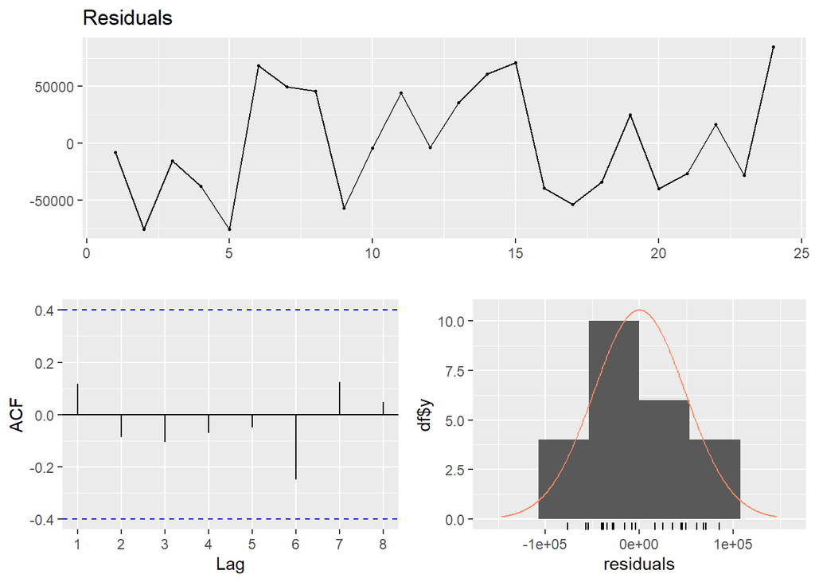

```r
checkresiduals(lm2$residuals)
```

This model significantly decreased the autocorrelation between residuals. It also gave a good p value and a high adjusted R-squared value of 0.8375.But the above model had better adjusted R-squred value.

Then the combination of both models is tried.Even though this model showed a better performance in terms of adjusted R-squre, in the model, lagged variable is not significant. Meaning that trend and seasonality variables did a good job explaining the effect of lagged variables. Therefore I decided to move on with the first model without the lagged output variable.

To improve the first model even further I tried to explain resiudals by the independent variables and checked which variables did a good job explaining the residuals. Only ndgv and nugv variables were significant. But from the first pairwise correlation graph, it was seen that nugv and ngdv variables have almost perfect correlation, thus I picked the more significant one, which was ndgv, to continue.

So in my final model, I used trend, seasonality and NDGV variables.

# final model

```r
lm3 =lm(ugs~qrtr+trnd+ndgv,data=petroldata) #ndgv nugv highly correlated.
summary(lm3)
```

```
##
## Call:
## lm(formula = ugs ~ qrtr + trnd + ndgv, data = petroldata)
##
## Residuals:
##    Min     1Q Median     3Q    Max
## -95177 -20446   4981  23434  58487
##
## Coefficients:
##             Estimate Std. Error t value Pr(>|t|)
## (Intercept) 324530.8   271194.7   1.197 0.244172
## qrtr2       120616.4    22985.2   5.248 2.90e-05 ***
## qrtr3       271579.1    23062.0  11.776 5.70e-11 ***
## qrtr4        90318.6    23226.3   3.889 0.000791 ***
## trnd        -18430.3     2077.4  -8.872 1.02e-08 ***
## ndgv          2710.7      996.1   2.721 0.012463 *
## ---
## Signif. codes:  0 '***' 0.001 '**' 0.01 '*' 0.05 '.' 0.1 ' ' 1
##
## Residual standard error: 42950 on 22 degrees of freedom
##   (4 observations deleted due to missingness)
## Multiple R-squared:  0.9341, Adjusted R-squared:  0.9191
## F-statistic: 62.37 on 5 and 22 DF,  p-value: 2.989e-12
```

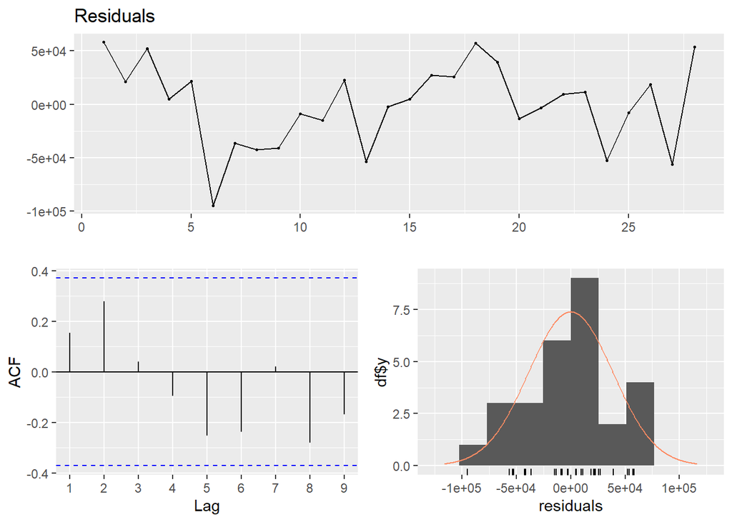

```r
checkresiduals(lm3$residuals)
```

This model gave the best performance. All variables are significant, has a small p value and a high adjusted R-squared value of 0.9191. It also has uncorrelated residuals, residuals seems to be random and close to normal distributed.

To observe visually, actual versus predicted graphs are built.

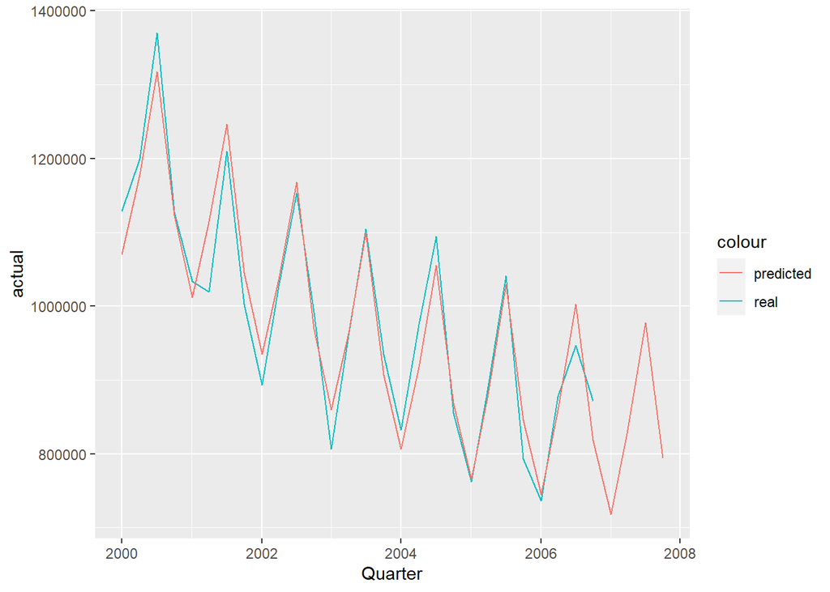

```r
tmp=copy(petroldata)
tmp[,actual:=ugs]
tmp[,predicted_trend:=predict(lm3,tmp)]
tmp[,residual_trend:=actual-predicted_trend]
#head(tmp)
ggplot(tmp ,aes(x=Quarter)) +
  geom_line(aes(y=actual,color='real')) +
  geom_line(aes(y=predicted_trend,color='predicted'))
```

As it can be seen from the graphs, they are pretty close. So I decided to move on with this model to make predictions of 2007 sales.

## Forecasting

```r
pr1=predict(lm3,newdata = petroldata[29:32])
pr1
```

```
##        1        2        3        4
## 717586.1 832696.3 977438.2 793592.4
```

Also I tried some other models in my R code, which weren’t useful, but I still included them in my code.